# U.S. Flight Delays in 2022

BIOS 611 Final Project

Madhuri Raman

December 14, 2023

# Preliminary Data Investigation

In this project, we will be investigating US flight delay data from 2022. This data was taken from Arvind Nagaonkar’s larger Flight Delay dataset on Kaggle (https://www.kaggle.com/datasets/arvindnagaonkar/flight-delay/data), which contains flight data from the Bureau of Transportation Statistics from January 2018 - April 2023. However, due to the size of the whole data set (~6 GB), we choose to only look at a subset of data, flights from 2022, for this project. We chose data from 2022 as it is representative of a nearly back-to-normal post-pandemic world. Thus, the trends we find should be the most similar to present day and useful for future predictions. We also chose to randomly sample one third of the data by month to maintain the uniform distribution of flights month by month.

Specifically, our data set contains observations of flights in 2022. As mentioned by Arvind Nagaonkar on his Kaggle notebook, the data includes information about flights’ scheduled and actual departure and arrival times. Note that this data set focuses on delayed flights, not cancelled or diverted flights. A detailed description of the columns can be found at the Kaggle link above.

First, we import our csv data set and explore the size and quality of the data. We check the number of observations and columns and in the data set, validate that the data types of each column variable are sensible, and check for any missing values.

When we examine the data types of each variable, we see that all of the data types look correct. Importantly, our date variable is numeric and also split into separate columns for day, month, and year. Thus, we can add/subtract integers to dates to move forward/backward in time, and we can easily work with individual days, months, and years if needed. Most of the other columns represent an amount of time, and all units are set to minutes, as specified in the Kaggle write up. We note that the last column looks irrelevant, so it can be removed. We also see that there are no missing values represented by NA in the data. In later histograms or barplots, if we come across any unusual values, we will be sure to consider the possibility of them representing missingness in the data and adjust our dataframe if necessary.

### Data Cleaning Check

As a sanity check, let’s first investigate the Time variables in our data to see if they make sense.

We need to ensure that departure time is always less than Arrival time. Let’s see how many observations exist in our data for which this does NOT hold true, and what percentage of observations they represent. About 4.5% of the observations have a departure time that is greater than the arrival time.

## Initial EDA

Now that we have verified that our Time variables look okay, we will now make some plots to visualize some univariate distributions and bivariate relationships in our data.

### Univariate EDA

#### Barplot of flights in 2022 by Month

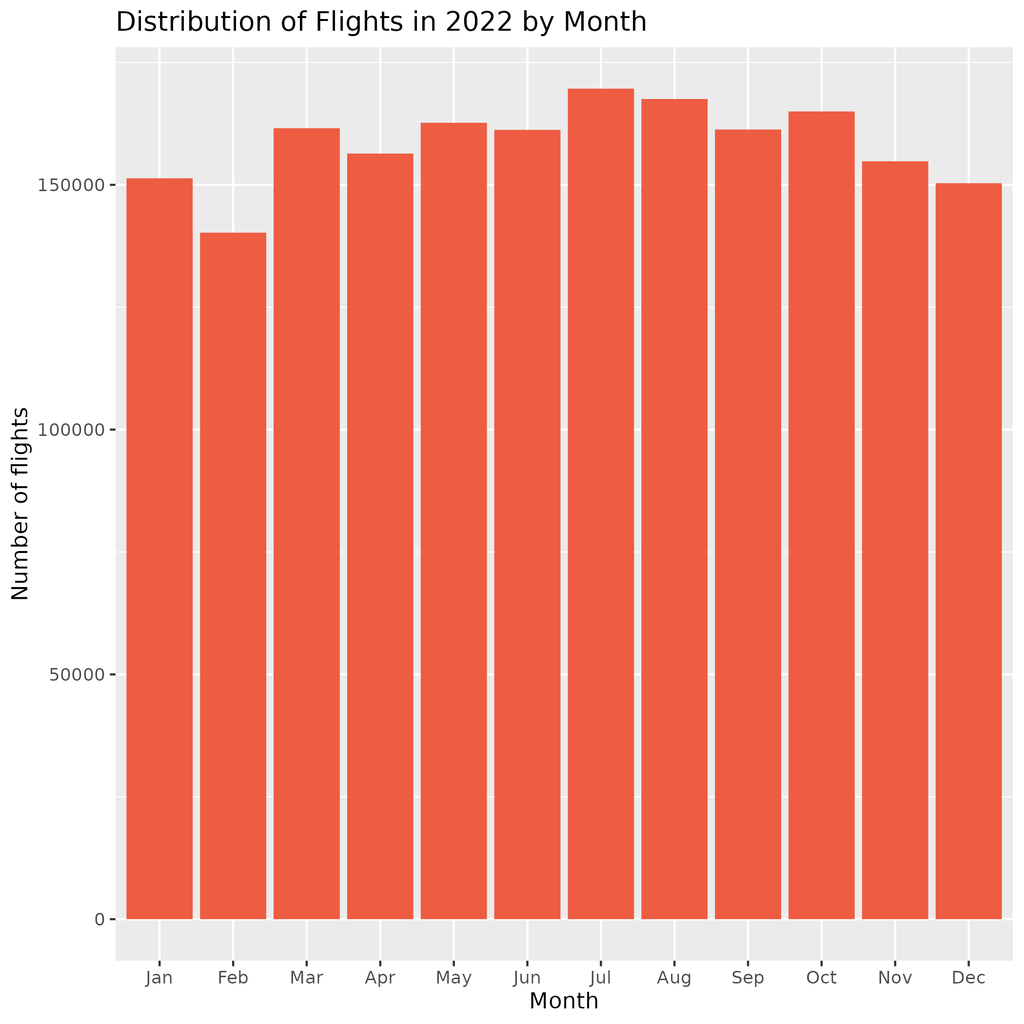

Barplot of flights in 2022 by Month

We see that the distribution of flights in our data set is relatively uniform across 2022. There is a slight increase in flights in the summer months compare to the winter months, with July 2022 having the most flights and February 2022 having the least. This seems sensible due to the cold weather in February (in most of the country). Additionally, most kids are on summer vacation in July so we expect vacations to be quite common that month.

#### Histogram of Departure Times

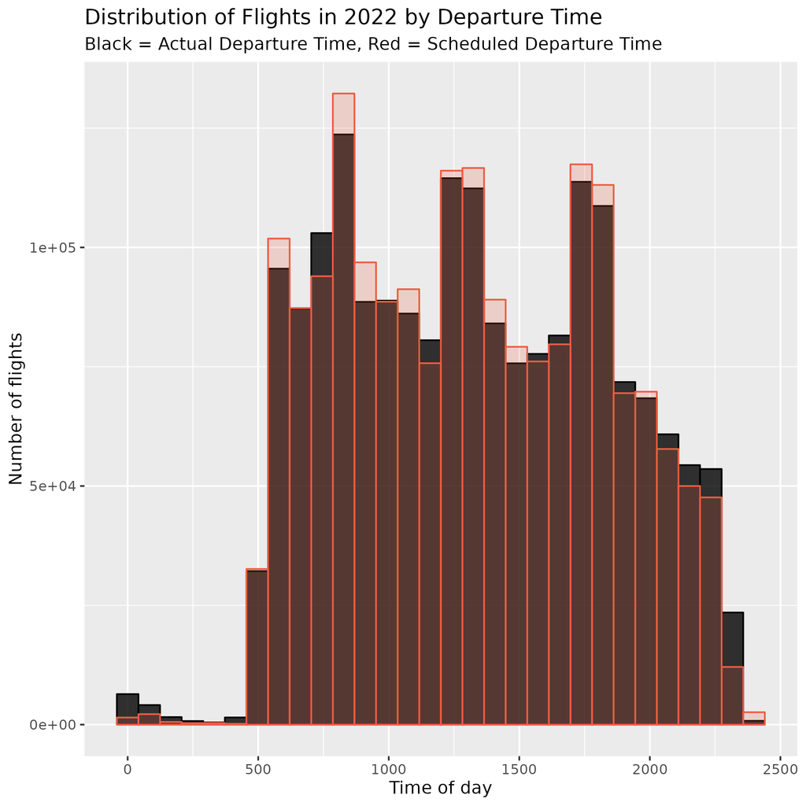

Histogram of Flight Departure Times in 2022

### Bivariate EDA

#### Barplot of Weather Delays by Airline Code

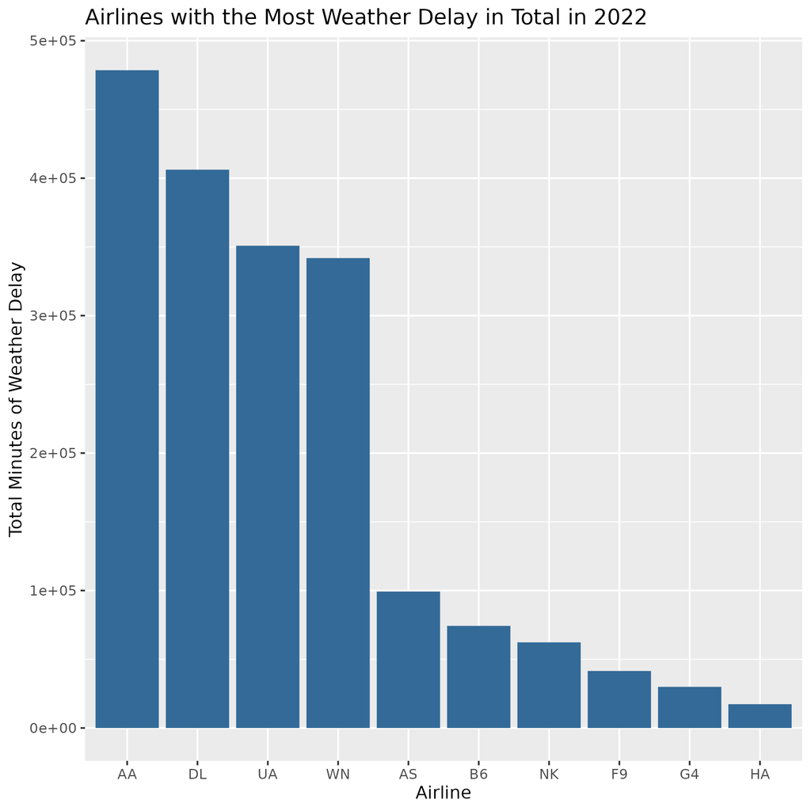

Weather Delays by Airline in 2022

#### Barplot of Flight Delays (overall) by Departure City

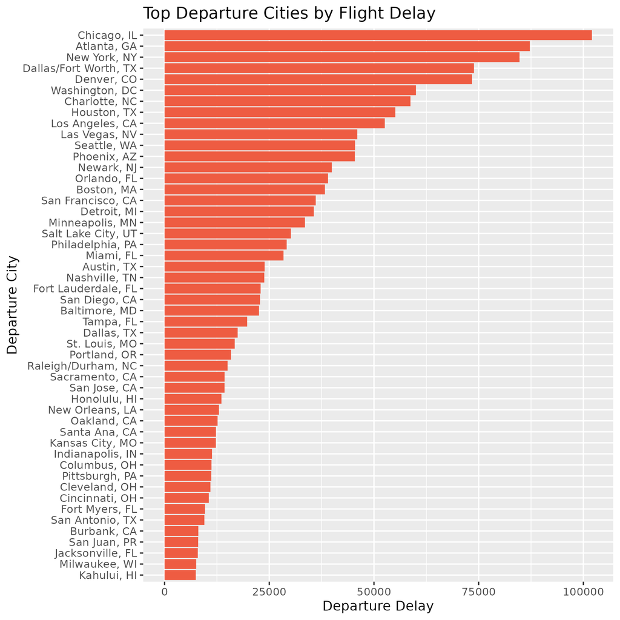

Overall Flight Delays by Departure City in 2022

When looking at the top departure cities for flights by amount of flight delay, we see that the three cities with highest amount of delay are Chicago, Atlanta, and New York, which are extremely unsurprising considering that everyone knows these are the three busiest airports in the country. Here, New York probably includes both La Guardia and JFK, which makes it interesting for it to still be in 3rd place compared to Chicago (O’Hare) and Atlanta (Hartsfield-Jackson) in terms of flight delay. Also, I am surprised that Charlotte is in the top 10 by flight delays, which I did not expect since it’s not a huge city. However, it seems to be a hub for connecting flights, especially American Airlines, which may lead to higher `LateAircraftDelay`. I have the same suspicion about Denver, which I have never been to but I believe is a hub for United Airlines and has similar issues.

## Dimensionality Reduction

### Principal Component Analysis

We now apply PCA to the flight delay dataset for the purposes of dimensionality reduction. First, we subset only the numeric columns of the data (end of “R_scripts/data_clean.r”), and then we applied PCA (“R_scripts/pca.r”). Then, we plotted the principal components against the cumulative variance explained.

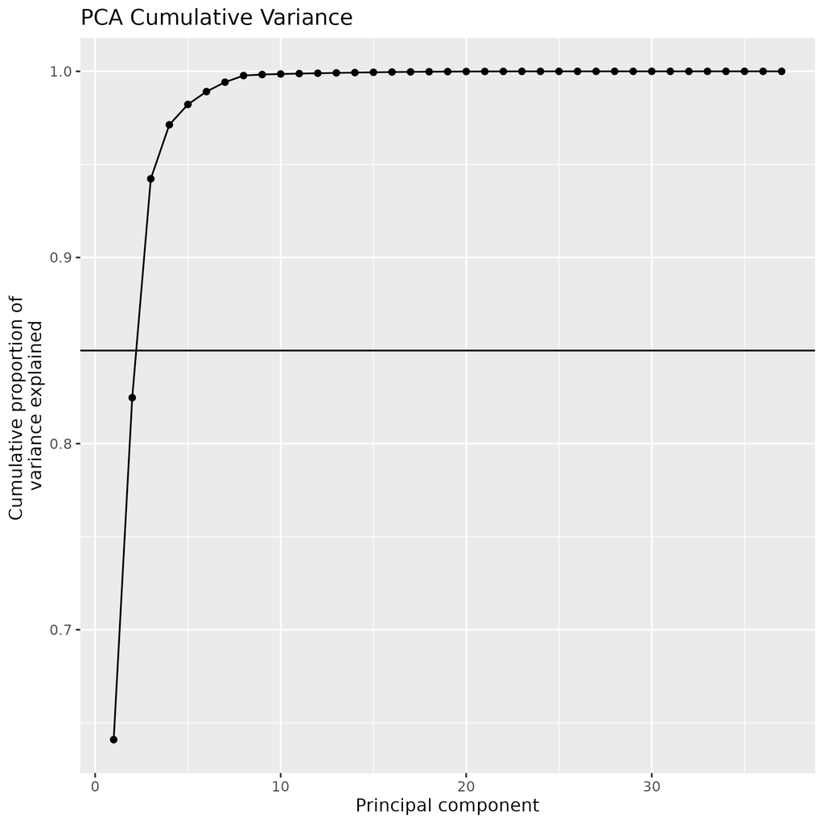

Cumulative Variance Explained by Principal Components

When we plot PC1 vs PC2 we see a very interesting geographical structure in the plot.

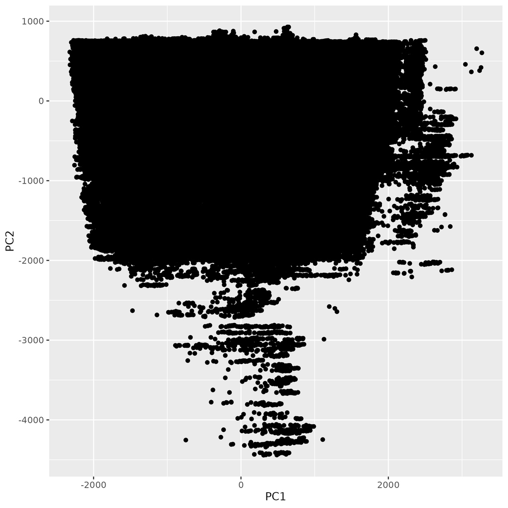

Specifically, the plot looks like a map of the United States! There is no information in the numeric dataframe about the flight cities or any latitudes and longitudes. There is only data about times and distance (in miles) between airports. Given that there are nearly 2 million flights in our dataset (which only represents one-third of 2022 flights), it makes sense that most combinations of airports around the country are represented such that the inherent geographical structure in the data is revealed by the first two principal components.

## Modeling

In this dataset, we are given data about scheduled vs. arrival times, as well as five different specific types of delays that sum to the overall flight delay time. These types of delays are:

- Carrier Delay, in Minutes
- Weather Delay, in Minutes
- National Air System Delay, in Minutes
- Security Delay, in Minutes
- Late Aircraft Delay, in Minutes

The biggest question that travelers (and their loved ones) have is:

*WHY IS MY FLIGHT DELAYED???*

Our goal now is to try to predict overall flight delay time from the five types of delays, and see which types contribute more significantly to the overall flight delay. First, let’s take a look at a correlation matrix between all five types of delays to see if there is any collinearity amongst those variables.

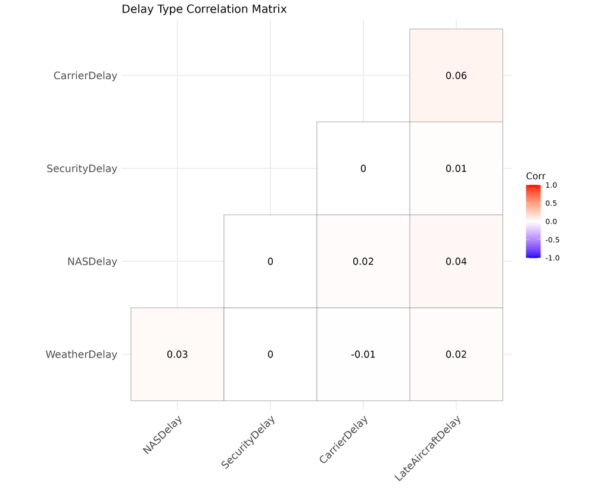

Correlation Matrix of Flight Delay Types

We see that the types of delay are highly uncorrelated with each other. Thus, there is no collinearity to worry about.

Finally, we run the following linear regression model:

$$DepDelay = \beta_0 + \beta_1Carrier +
\beta_2 Weather + \beta_3 NAS + \beta_4Security + \beta_5 LateAircraft +
\epsilon$$

The following table is a summary of the regression output:

```r
regdata <- read.csv("derived_data/linear_regression_output.csv")
knitr::kable(regdata)
```

| Coefficient | Std_Error | t_value | P_Values |
| --- | --- | --- | --- |
| -2.8408399 | 0.0077186 | -368.0515 | 0 |
| 1.0235421 | 0.0001877 | 5452.2881 | 0 |
| 0.9920414 | 0.0004609 | 2152.3487 | 0 |
| 0.7056114 | 0.0004832 | 1460.2065 | 0 |
| 1.0607178 | 0.0049408 | 214.6862 | 0 |
| 1.0472895 | 0.0002418 | 4331.8966 | 0 |

## Discussion and Future Work

This project was very interesting, but I was definitely limited by time in terms of what I could look into. Additionally, I was limited by the free computing powers I had, so I was only able to analyze one-third of the 2022 flights. A full-time data scientist with the money and resources of Corporate America should really use all 5-6 years of data!

The following are a list of ideas and questions that can be investigated through this data set that would provide even more insight into the who/what/when/where/why/hows of flight delays in the US:

- Airlines with “hubs” at specific airports: are they more efficient than other airlines at those same airports? or are they less efficient? For example, does it make sense for Charlotte to be a “hub” for American Airlines, or would there be less delays overall if it wasn’t? (I suspect that hubs are a good thing, since intra-airline cooperation is probably better than inter-airline cooperation at an airport)
- What is the primary reason for delay at each airport or in each region of the US? (I suspect weather delay anywhere that gets snow, but who knows!)
- Modeling flight delay time from all variables in this data set, plus any supplemental data about each airport, airline, aircraft, etc. A singular model that could predict the exact amount of flight delay (regardless of why) that a traveler may expect to face, given ALL POSSIBLE FACTORS (time of day, time of year, everything!) could probably work wonders and be sold to airports and airlines for many many dollars.

# Thank you for reading :)